# Stats 20 Homework 7 Solutions

Winter 2022

Edouardo Honig and Michael Tsiang – 123456789

01/12/22

**Note: These solutions are owned by the authors listed above and are intended for personal use only for the students enrolled in Stats 20 in Winter 2022. Any other use is strictly prohibited. Any of these solutions, in whole or in part, may not be posted online or shared with anyone at any time in any form (e.g., verbally, electronically, physically) without explicit written permission by the instructor (Michael Tsiang), *even after the quarter is over*. Failure to comply is facilitating dishonesty and a breach of academic integrity.**

## Question 1

### (a)

```r
births <- read.csv("births.csv", stringsAsFactors = TRUE)
dim(births)
```

```
## [1] 1998   21
```

```r
head(births)
```

```
##   Gender Premie weight Apgar1 Fage Mage Feduc Meduc TotPreg Visits   Marital
## 1   Male     No    124      8   31   25    13    14       1     13   Married
## 2 Female     No    177      8   36   26     9    12       2     11 Unmarried
## 3   Male     No    107      3   30   16    12     8       2     10 Unmarried
## 4 Female     No    144      6   33   37    12    14       2     12 Unmarried
## 5   Male     No    117      9   36   33    10    16       2     19   Married
## 6 Female     No     98      4   31   29    14    16       3     20   Married
##   Racemom Racedad Hispmom Hispdad Gained     Habit MomPriorCond BirthDef
## 1   White   White NotHisp NotHisp     40 NonSmoker         None     None
## 2   White   White Mexican Mexican     20 NonSmoker         None     None
## 3   White Unknown Mexican Unknown     70 NonSmoker At Least One     None
## 4   White   White NotHisp NotHisp     50 NonSmoker         None     None
## 5   White   Black NotHisp NotHisp     40 NonSmoker At Least One     None
## 6   White   White NotHisp NotHisp     21 NonSmoker         None     None
##      DelivComp BirthComp
## 1 At Least One      None
## 2 At Least One      None
## 3 At Least One      None
## 4 At Least One      None
## 5         None      None
## 6         None      None
```

```r
## OR
# str(births)
```

### (b)

```r
habit_tbl <- table(births$Habit)
habit_tbl
```

```
##
##           NonSmoker    Smoker
##         6      1805       187
```

```r
names(habit_tbl)
```

```
## [1] ""          "NonSmoker" "Smoker"
```

There are 6 observations in this category which has as a name an empty string, "".

### (c)

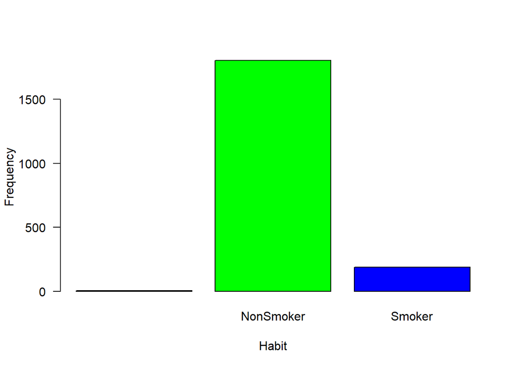

```r
barplot(habit_tbl, col = rainbow(length(habit_tbl)), las = 1,
        xlab = "Habit", ylab = "Frequency")
```

### (d)

```r
q1d <- droplevels(births[!(births$Habit == ""), ])
table(q1d$Habit)
```

```
##
## NonSmoker    Smoker
##      1805       187
```

### (e)

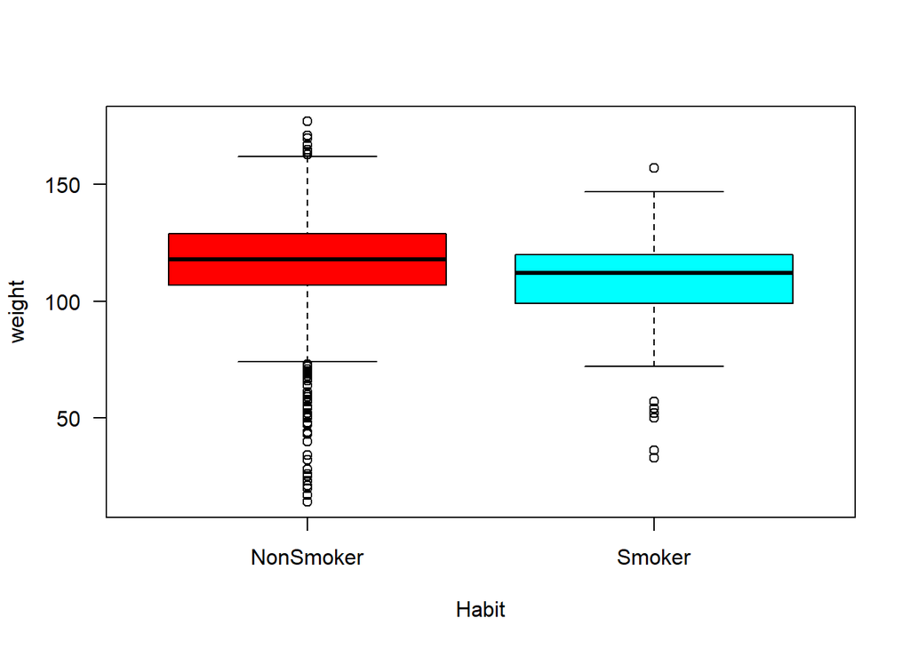

```r
boxplot(weight ~ Habit, data = q1d,
        col = rainbow(length(levels(q1d$Habit))), las = 1)
```

## Question 2

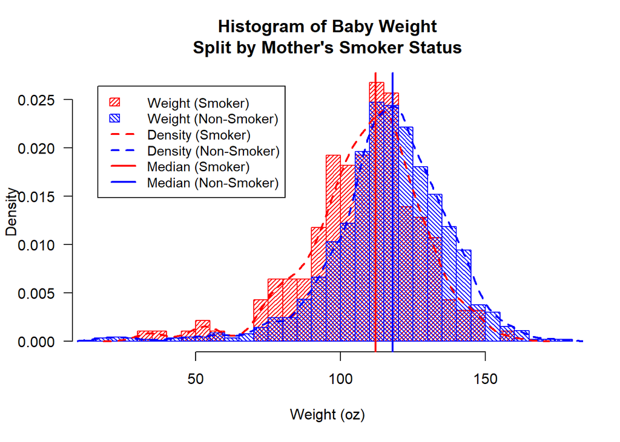

```r
w_sm <- q1d$weight[q1d$Habit == "Smoker"]
w_nsm <- q1d$weight[q1d$Habit == "NonSmoker"]

hist(w_sm,
     freq = FALSE,
     col = "red",
     breaks = 30,
     density = 30,
     xlab = "Weight (oz)",
     xlim = range(q1d$weight),
     las = 1,
     main = "Histogram of Baby Weight\nSplit by Mother's Smoker Status"
)
hist(w_nsm,
     freq = FALSE,
     col = "blue",
     breaks = 30,
     density = 30,
     angle = -45,
     add = TRUE
)
lines(density(w_sm), col = "red", lty = 2, lwd = 2)
lines(density(w_nsm), col = "blue", lty = 2, lwd = 2)
abline(v = median(w_sm), col = "red", lwd = 2)
abline(v = median(w_nsm), col = "blue", lwd = 2)
legend("topleft",
       legend = c("Weight (Smoker)", "Weight (Non-Smoker)",
                  "Density (Smoker)", "Density (Non-Smoker)",
                  "Median (Smoker)", "Median (Non-Smoker)"),
       fill = c("red", "blue", rep(0, 4)),
       border = c("red", "blue", rep(NA, 4)),
       col = c("red", "blue"),
       lty = c(NA, NA, 2, 2, 1, 1),
       angle = c(45, -45, rep(NA, 4)),
       lwd = 2,
       density = c(30, 30, rep(NA, 4)),
       pch = NA,
       inset = 0.05,
       cex = 0.9
)
```

## Question 3

### (a)

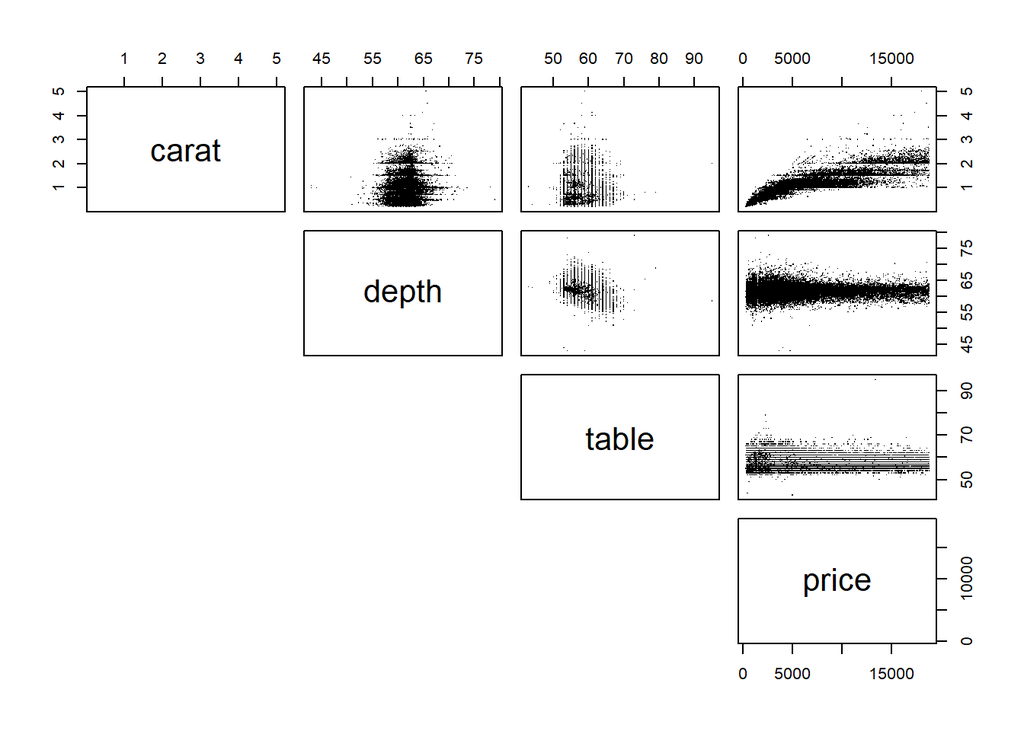

```r
library(ggplot2)
data(diamonds)
pairs(diamonds[c(1, 5:7)], lower.panel = NULL, pch = ".")
```

According to the scatterplots, carat and price appear to have the strongest nonlinear relationship, which appears to be logarithmic.

### (b)

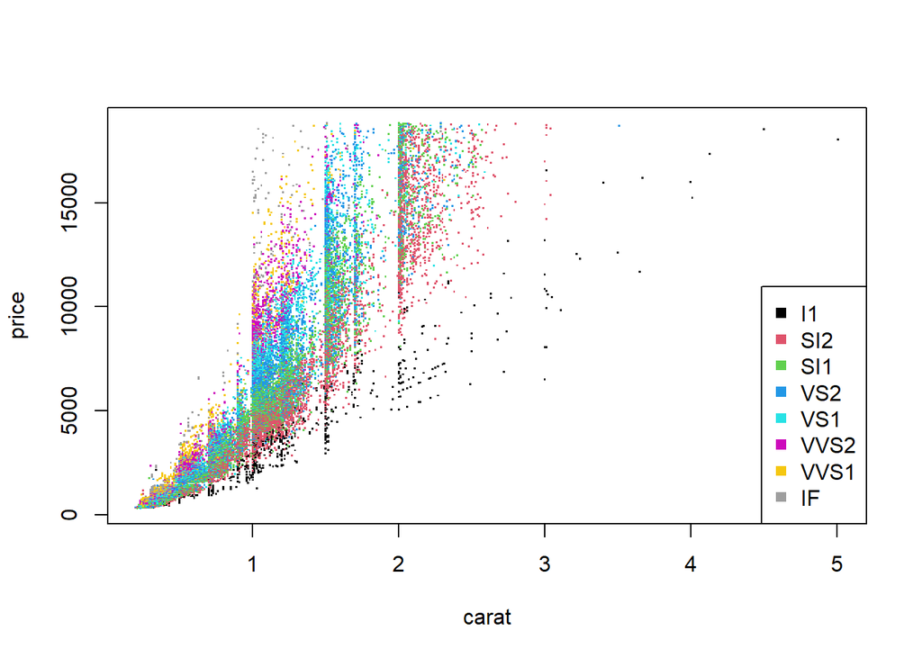

```r
with(diamonds, {
  plot(price ~ carat, pch = 15, cex = 0.2, col = clarity)
  legend("bottomright", legend = levels(clarity), pch = 15, col = 1:8)
})
```

Since `clarity` is a(n) (ordered) factor with 8 levels, `col = clarity` causes the color for each ordered level to start at 1 and go in whole number sequence up to 8. This is because factors are stored as integers, so `col` uses the stored integer version (which corresponds to the indices of the levels) of `clarity` to assign colors. You would see the same result if we used `col = as.integer(clarity)`.

### (c)

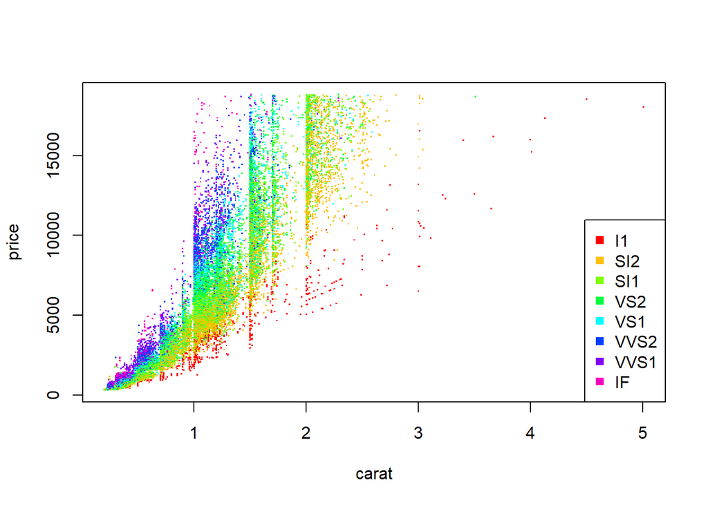

```r
with(diamonds, {
  plot(price ~ carat, pch = 15, cex = 0.2, col = rainbow(8)[clarity])
  legend("bottomright", legend = levels(clarity), pch = 15, col = rainbow(8))
})
```

### (d)

The higher the order of clarity and amount of carats, the higher price a diamond will have.

## Question 4

### (a)

```r
q4a <- with(diamonds, tapply(price, list(color, cut), mean))
q4a
```

```
##       Fair     Good Very Good  Premium    Ideal
## D 4291.061 3405.382  3470.467 3631.293 2629.095
## E 3682.312 3423.644  3214.652 3538.914 2597.550
## F 3827.003 3495.750  3778.820 4324.890 3374.939
## G 4239.255 4123.482  3872.754 4500.742 3720.706
## H 5135.683 4276.255  4535.390 5216.707 3889.335
## I 4685.446 5078.533  5255.880 5946.181 4451.970
## J 4975.655 4574.173  5103.513 6294.592 4918.186
```

### (b)

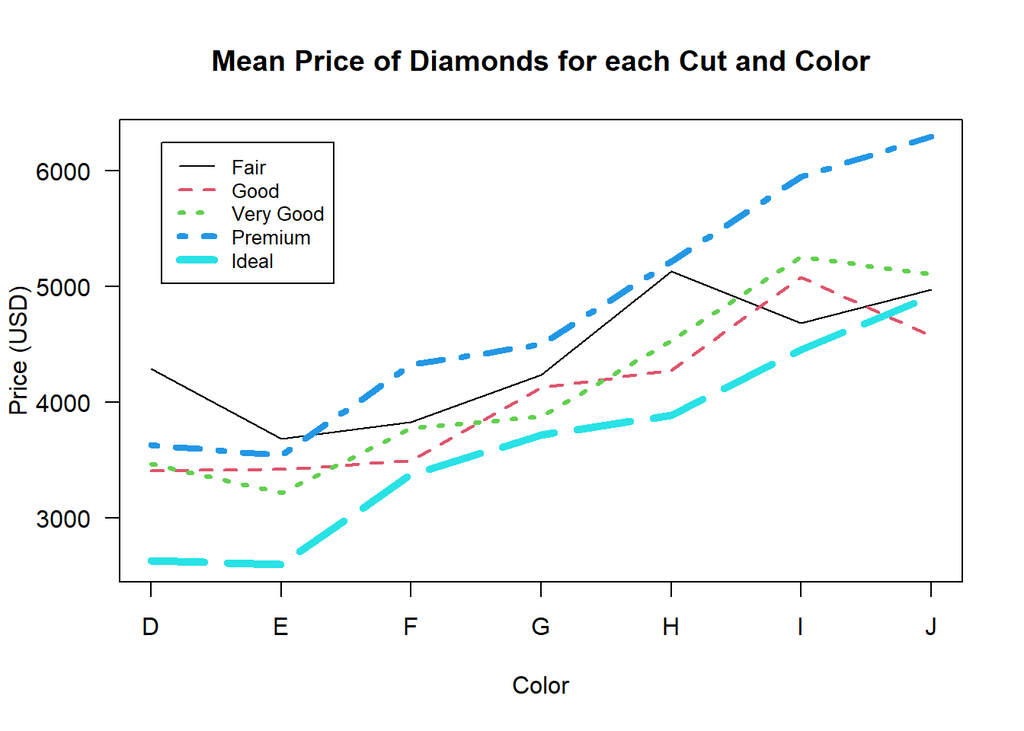

```r
matplot(q4a,
        type = "l",
        lty = 1:5,
        lwd = 1:5,
        col = 1:5,
        xaxt = "n",
        las = 1,
        xlab = "Color",
        ylab = "Price (USD)",
        main = "Mean Price of Diamonds for each Cut and Color"
)
axis(1, at = 1:7, labels = levels(diamonds$color))
legend("topleft",
       legend = levels(diamonds$cut),
       lty = 1:5,
       lwd = 1:5,
       col = 1:5,
       inset = 0.05,
       cex = 0.8
)
```

### (c)

As the ordered level of color increases, mean price of diamonds increase. “Premium” and then “Fair” cuts on average have higher mean price than others for the majority of colors.